# Vulnerability Hatstall

[figure not shown]

# Objective

Sorting vulnerabilities from different scanners using a machine learning model.

[figure not shown]

# Scope

Due to bigness of this project, we are only classify all the vulnerabilities from Openvas, mainly because it is open source and its plugins can be downloaded from free.

[figure not shown]

# Reasons

- Mainly because we need it in our job. We have been looking for the way to make vulnerability management easier.
- Many companies work with a lot of vulnerabilities scanners, and this is the way to normalize the results for all of those tools.
- We have never found anybody who works in something similar.
- There are not many data-science projects about cybersecurity, just search in [kaggle](https://www.kaggle.com) "cycbersecurity" and you will found out.
- It is a good way to practice data cleaning and wrangling and change our mind paradigm.
- Because I want and I can 😜

# Data

- We are going to work with official feeds from Openvas, data is public.

[figure not shown]

# Execution plan

```python
with open('../PluginsCategorization/Openvas/Samples/gb_adobe_acrobat_2017_apsb19-02_win.nasl','rb') as filename:
    myblock = get_block_of_text("if(description)", "include(", filename)
    for block in myblock:
        print(block)
```

```
b'{\n'
b'  script_oid("1.3.6.1.4.1.25623.1.0.814805");\n'
b'  script_version("$Revision: 13316 $");\n'
b'  script_cve_id("CVE-2018-16011", "CVE-2018-16018");\n'
b'  script_tag(name:"cvss_base", value:"9.3");\n'
b'  script_tag(name:"cvss_base_vector", value:"AV:N/AC:M/Au:N/C:C/I:C/A:C");\n'
b'  script_tag(name:"last_modification", value:"$Date: 2019-01-28 08:41:51 +0100 (Mon, 28 Jan 2019) $");\n'
b'  script_tag(name:"creation_date", value:"2019-01-04 11:36:03 +0530 (Fri, 04 Jan 2019)");\n'
b'\n'
b'  script_name("Adobe Acrobat 2017 Security Updates(apsb19-02)-Windows");\n'
b'\n'
b'  script_tag(name:"summary", value:"This host is installed with Adobe Acrobat 2017\n'
b'  and is prone to multiple vulnerabilities.");\n'
b'\n'
b'  script_tag(name:"vuldetect", value:"Checks if a vulnerable version is present\n'
b'  on the target host.");\n'
b'\n'
b'  script_tag(name:"insight", value:"Multiple flaws exist due to,\n'
b'\n'
b'  - Use after free error.\n'
b'\n'
b'  - Security bypass error.");\n'
b'\n'
b'  script_tag(name:"impact", value:"Successful exploitation will allow an\n'
b'  attacker to conduct arbitrary code execution in the context of the current\n'
b'  user and escalate privileges.");\n'
b'\n'
b'  script_tag(name:"affected", value:"Adobe Acrobat 2017 version 2017.011.30110\n'
b'  and earlier on Windows.");\n'
b'\n'
b'  script_tag(name:"solution", value:"Upgrade to Adobe Acrobat 2017.011.30113 or later.\n'
b'  For updates refer to Reference links.");\n'
b'\n'
b'  script_tag(name:"solution_type", value:"VendorFix");\n'
b'  script_tag(name:"qod_type", value:"registry");\n'
b'  script_xref(name:"URL", value:"https://helpx.adobe.com/security/products/acrobat/apsb19-02.html");\n'
b'  script_xref(name:"URL", value:"https://helpx.adobe.com");\n'
b'  script_category(ACT_GATHER_INFO);\n'
b'  script_copyright("Copyright (C) 2019 Greenbone Networks GmbH");\n'
b'  script_family("General");\n'
b'  script_dependencies("secpod_adobe_prdts_detect_win.nasl");\n'
b'  script_mandatory_keys("Adobe/Acrobat/Win/Ver");\n'
b'  exit(0);\n'
b'}\n'
b'\n'
```

```python
import pandas as pd
openvas_df = pd.read_csv('../PluginsCategorization/Openvas/Output/OpenvasSample.csv')
openvas_df.sample(5)
```

|  | OID | SolutionCategory | PluginFile | PluginFamily |
| --- | --- | --- | --- | --- |
| 1291 | 812657 | ToDiscard | gb_master_ip_camera01_detect.nasl | Product detection |
| 11157 | 103608 | ToClassify | gb_dotProject_lfi_11_12.nasl | Web application abuses |
| 28943 | 803513 | ToClassify | gb_nmap6_http_malware_host.nasl | Nmap NSE |
| 23500 | 122863 | Patch installation | ELSA-2016-0074.nasl | Oracle Linux Local Security Checks |
| 42450 | 863399 | Patch installation | gb_fedora_2011_9652_system-config-firewall_fc1... | Fedora Local Security Checks |

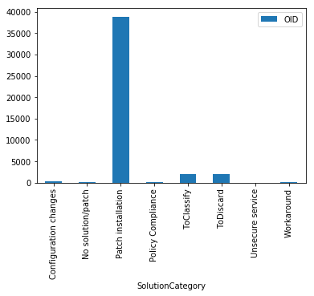

```python
openvas_df.groupby(['SolutionCategory']).count().loc[:,['OID']].plot.bar();
```

# Tools

[figure not shown]

# References

- http://www.lmgtfy.com/?q=vulnerability+management
- https://whatis.techtarget.com/definition/Vulnerability_management
- https://www.tripwire.com/state-of-security/vulnerability-management/what-is-vulnerability-management-anyway/
- https://www.kaggle.com/vsathiamoo/cve-common-vulnerabilities-and-exposures
- https://www.kaggle.com/walterhaydock/cybersecurity-vulnerability-analysis-with-k-means

# Ham for teacher

[figure not shown]